# Background

This analysis utilizes data from the Boston Housing Study to advise a real estate brokerage firm on market value. The Boston Housing data is comprised of 506 census tracts and contains information on houses as well as their surrounding area. Using all available data points, except neighborhood, this analysis explores home value through various regression methods. Ultimately, one model is chosen and recommended to the real estate brokerage firm.

# Data Initiation

We begin the analysis by reading in the data and performing some initial data exploration. These steps help to inform the scope of the exploratory data analysis section.

```python
RANDOM_SEED = 42

# import packages
import pandas as pd
import numpy as np
import matplotlib.pyplot as plt
import seaborn as sns

# for model building and results
from sklearn.linear_model import LinearRegression, Ridge, Lasso, ElasticNet
from sklearn.metrics import make_scorer, mean_squared_error, r2_score, mean_absolute_error
from math import sqrt
from sklearn.model_selection import cross_validate, cross_val_score, cross_val_predict, train_test_split
from sklearn.preprocessing import StandardScaler

# for display
from prettytable import PrettyTable
```

```python
# read in our data
boston_df = pd.read_csv('boston.csv')
boston_df = boston_df.loc[:, boston_df.columns != 'neighborhood'] #remove this right away

boston_df.info()
boston_df.describe() #do see that there is a range in values
#boston_df["neighborhood"].unique() #let's explore neighborhood - there are 93 distinct vals!
```

```
<class 'pandas.core.frame.DataFrame'>
RangeIndex: 506 entries, 0 to 505
Data columns (total 13 columns):
crim       506 non-null float64
zn         506 non-null float64
indus      506 non-null float64
chas       506 non-null int64
nox        506 non-null float64
rooms      506 non-null float64
age        506 non-null float64
dis        506 non-null float64
rad        506 non-null int64
tax        506 non-null int64
ptratio    506 non-null float64
lstat      506 non-null float64
mv         506 non-null float64
dtypes: float64(10), int64(3)
memory usage: 51.5 KB
```

|  | crim | zn | indus | chas | nox | rooms | age | dis | rad | tax | ptratio | lstat | mv |
| --- | --- | --- | --- | --- | --- | --- | --- | --- | --- | --- | --- | --- | --- |
| count | 506.000000 | 506.000000 | 506.000000 | 506.000000 | 506.000000 | 506.000000 | 506.000000 | 506.000000 | 506.000000 | 506.000000 | 506.000000 | 506.000000 | 506.000000 |
| mean | 3.613524 | 11.363636 | 11.136779 | 0.069170 | 0.554695 | 6.284634 | 68.574901 | 3.795043 | 9.549407 | 408.237154 | 18.455534 | 12.653063 | 22.528854 |
| std | 8.601545 | 23.322453 | 6.860353 | 0.253994 | 0.115878 | 0.702617 | 28.148861 | 2.105710 | 8.707259 | 168.537116 | 2.164946 | 7.141062 | 9.182176 |
| min | 0.006320 | 0.000000 | 0.460000 | 0.000000 | 0.385000 | 3.561000 | 2.900000 | 1.129600 | 1.000000 | 187.000000 | 12.600000 | 1.730000 | 5.000000 |
| 25% | 0.082045 | 0.000000 | 5.190000 | 0.000000 | 0.449000 | 5.885500 | 45.025000 | 2.100175 | 4.000000 | 279.000000 | 17.400000 | 6.950000 | 17.025000 |
| 50% | 0.256510 | 0.000000 | 9.690000 | 0.000000 | 0.538000 | 6.208500 | 77.500000 | 3.207450 | 5.000000 | 330.000000 | 19.050000 | 11.360000 | 21.200000 |
| 75% | 3.677082 | 12.500000 | 18.100000 | 0.000000 | 0.624000 | 6.623500 | 94.075000 | 5.188425 | 24.000000 | 666.000000 | 20.200000 | 16.955000 | 25.000000 |
| max | 88.976200 | 100.000000 | 27.740000 | 1.000000 | 0.871000 | 8.780000 | 100.000000 | 12.126500 | 24.000000 | 711.000000 | 22.000000 | 37.970000 | 50.000000 |

After reading in the data and removing the neighborhood variable, as this variable is out of scope, we can see that all values are numeric. Additionally, through the summary statistics, we can see that there is a range in values. For instance, the tax rate variable has a wide range with large numbers, whereas the air pollution variable (nox) seems to only have values between 0 and 1. This observation is important, as it means that for modeling, all variables will need to be standardized so that they are on a similar scale.

Finally, we quick check if there are missing values that need to be handled before modeling.

```python
# is there missing data?
print(boston_df.isnull().sum())
# from the output below, there is no missing data
```

[output not shown]

From the output above, we can see that there are no missing values. Therefore, we are ready to dive into the exploratory data analysis.

# Exploratory Data Analysis

## Univariate Analysis

We begin the exploratory data analysis by first assessing the distribution of the response variable, which is median home value. A violin plot and histogram are generated, as they reveal different information.

```python
current_palette = sns.color_palette() #10 colors
```

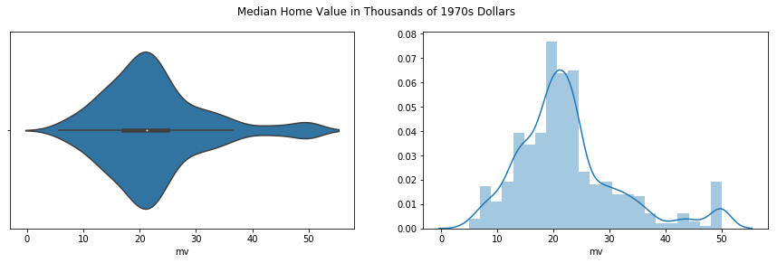

```python
import warnings
warnings.simplefilter(action='ignore', category=FutureWarning)

fig, axes = plt.subplots(nrows=1, ncols=2, figsize = (15,4))
fig.suptitle("Median Home Value in Thousands of 1970s Dollars")

ax = axes[0]
sns.violinplot(x = boston_df["mv"], color = current_palette[0], ax=ax)

ax = axes[1]
sns.distplot(boston_df["mv"], color = current_palette[0], ax=ax)
```

From the violin plot, we can more readily see that the median home value is just above 20. Moreover, we can see that the distribution is not symmetric. In other words, the distribution is right skewed. With the histogram, we can better see that the response variable is not centered. Variable transformation may be considered to help improve model results. We can also better see that there is an increase in home values near 50.

It is worth calling out that although the neighborhood variable was excluded from this analysis, that variable could add value in the future by helping to reduce the range of the home values considered, as they are very broad.

Next, we will analyze all the predictors independently before considering bi-variate analysis.

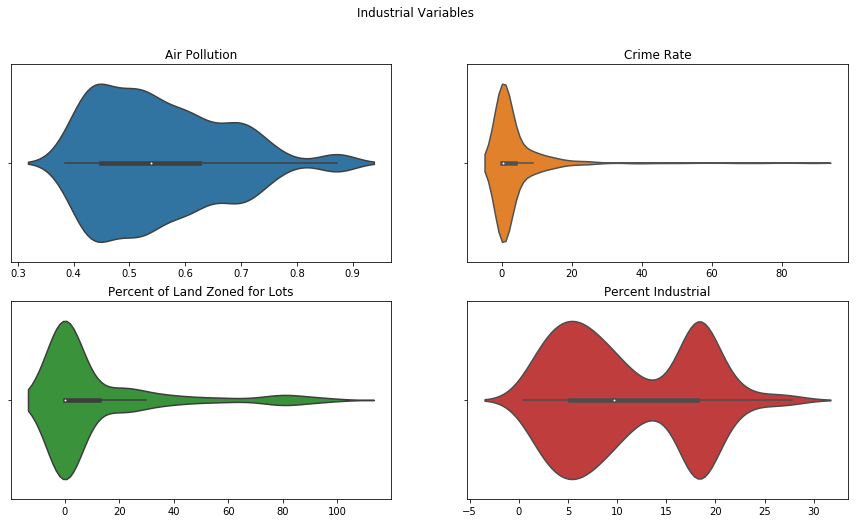

```python
# let's look at some more vars
fig, axes = plt.subplots(nrows=2, ncols=2, figsize = (15,8))
fig.suptitle('Industrial Variables')
#fig.tight_layout()

ax1 = axes[0,0]
sns.violinplot(x = boston_df["nox"], color = current_palette[0], ax=ax1).set_title("Air Pollution")
ax1.set_xlabel('')

ax2 = axes[0,1]
sns.violinplot(x = boston_df["crim"], color = current_palette[1], ax=ax2).set_title("Crime Rate")
ax2.set_xlabel('')

ax3 = axes[1,0]
sns.violinplot(x = boston_df["zn"], color = current_palette[2], ax=ax3).set_title("Percent of Land Zoned for Lots")
ax3.set_xlabel('')

ax4 = axes[1,1]
sns.violinplot(x = boston_df["indus"], color = current_palette[3], ax=ax4).set_title("Percent Industrial")
ax4.set_xlabel('')
```

From the violin plots above, we can see that crime rate and percent of land zoned for lots are higly right skewed. This result makes sense since there would be fewer instances of high values and greater concentration of low values. From the percent industrial plot, we can see there is a bimodal distribution. While the median value is about 10%, there are values near 30. Overall, there is a higher concentration of values near 5% and 20%. The air pollution distribution has some skewness and increase in values near .9.

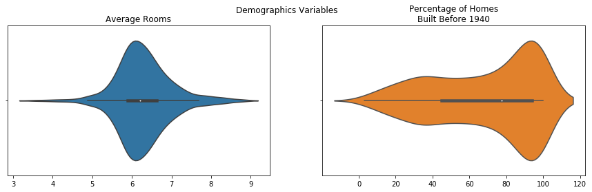

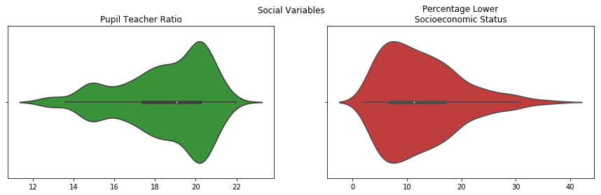

```python
fig, axes = plt.subplots(nrows=1, ncols=2, figsize = (15,4))
fig.suptitle('Demographics Variables')
#fig.tight_layout()

ax1 = axes[0]
sns.violinplot(x = boston_df["rooms"], color = current_palette[0], ax=ax1).set_title("Average Rooms")
ax1.set_xlabel('')

ax2 = axes[1]
sns.violinplot(x = boston_df["age"], color = current_palette[1], ax=ax2).set_title("Percentage of Homes\nBuilt Before 1940")
ax2.set_xlabel('')

fig, axes = plt.subplots(nrows=1, ncols=2, figsize = (15,4))
fig.suptitle('Social Variables')
ax3 = axes[0]
sns.violinplot(x = boston_df["ptratio"], color = current_palette[2], ax=ax3).set_title("Pupil Teacher Ratio")
ax3.set_xlabel('')

ax4 = axes[1]
sns.violinplot(x = boston_df["lstat"], color = current_palette[3], ax=ax4).set_title("Percentage Lower\nSocioeconomic Status")
ax4.set_xlabel('')
```

From the demographics variables above, we can see that the rooms variable is fairly symmetrical with a median value just above 6 rooms. In contrast, we can see that there are more homes that were built before 1940. It could be interesting to explore this variable in greater detail to see if the house profiles are different for homes built before 1940 or not, and if there is a higher concentration of these homes in certain neighborhoods. This is all to say that like the home value variable, a house's age could be used to filter the data set to better answer the mangaement problem.

Pupil to Teacher ratio is left skewed, while socioeconomic status is right skewed.

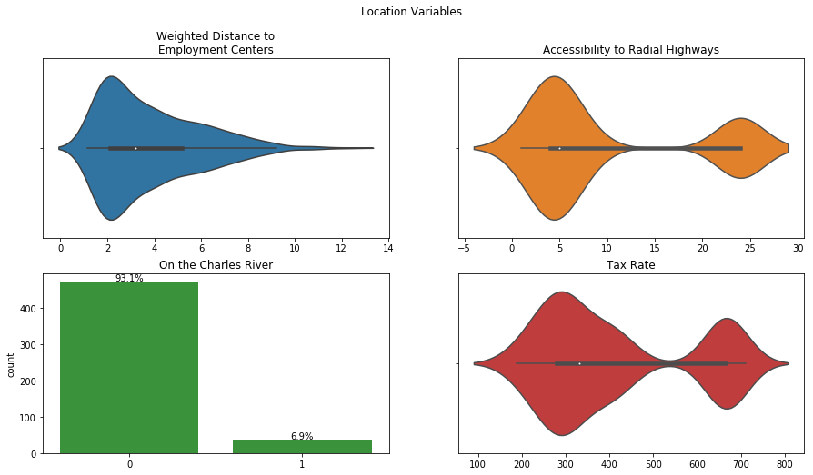

```python
# let's look at some more vars
fig, axes = plt.subplots(nrows=2, ncols=2, figsize = (15,8))
fig.suptitle('Location Variables')
#fig.tight_layout()

ax1 = axes[0,0]
sns.violinplot(x = boston_df["dis"], color = current_palette[0], ax=ax1).set_title("Weighted Distance to\nEmployment Centers")
ax1.set_xlabel('')

ax2 = axes[0,1]
sns.violinplot(x = boston_df["rad"], color = current_palette[1], ax=ax2).set_title("Accessibility to Radial Highways")
ax2.set_xlabel('')

ax3 = axes[1,0]
total = float(len(boston_df))
ax = sns.countplot(x = "chas", data = boston_df, color = current_palette[2], ax=ax3)
for p in ax.patches:
    height = p.get_height()
    ax.text(p.get_x()+p.get_width()/2.,
            height + 3,
            '{:1.1f}%'.format(height/total*100),
            ha="center")
ax3.set_xlabel('')
ax3.set_title("On the Charles River")

ax4 = axes[1,1]
sns.violinplot(x = boston_df["tax"], color = current_palette[3], ax=ax4).set_title("Tax Rate")
ax4.set_xlabel('')
```

Lastly, from the location variables, we can see that radial highways and tax rates have a bimodal distribution. Once again, the neighborhood variable may help to reveal trends in these variables. The home value variable may also be helpful here to provide context. We can also see that most homes are not on the Charles River, and several homes are in closer proximity to employment centers.

From the univariate analysis, we have seen that many variables are skewed/not-normal, and some variables demostrate a bimodal distribution. This information is important to keep in mind, as certain modeling methods require that certain assumptions be met.

## Bivariate Analysis

We begin the bivariate analysis by examining the non continuous variables, Charles River and Radial Highways, in closer detail.

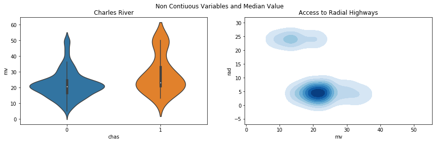

```python
fig, axes = plt.subplots(nrows=1, ncols=2, figsize = (15,4))
fig.suptitle('Non Contiuous Variables and Median Value')

ax1 = axes[0]
sns.catplot(x="chas", y="mv", kind="violin", data=boston_df, ax = ax1)
ax1.set_title('Charles River')

ax2 = axes[1]
sns.kdeplot(boston_df['mv'], boston_df['rad'], shade=True, shade_lowest=False, cmap = "Blues", ax=ax2)
ax2.set_title('Access to Radial Highways')

plt.close(2) #need this b/c extra blank plots are being created
```

From the Charles River visual, we can see that homes on the Charles River have a wider distribution in median home value. This result makes sense, as location has the potential to increase home value. However, we can see that the median values are fairly similar.

Thus, it seems like both of these predictors could be helpful in predicting median home value.

We continue the analysis by examining a correlation matrix between all variables in the data set.

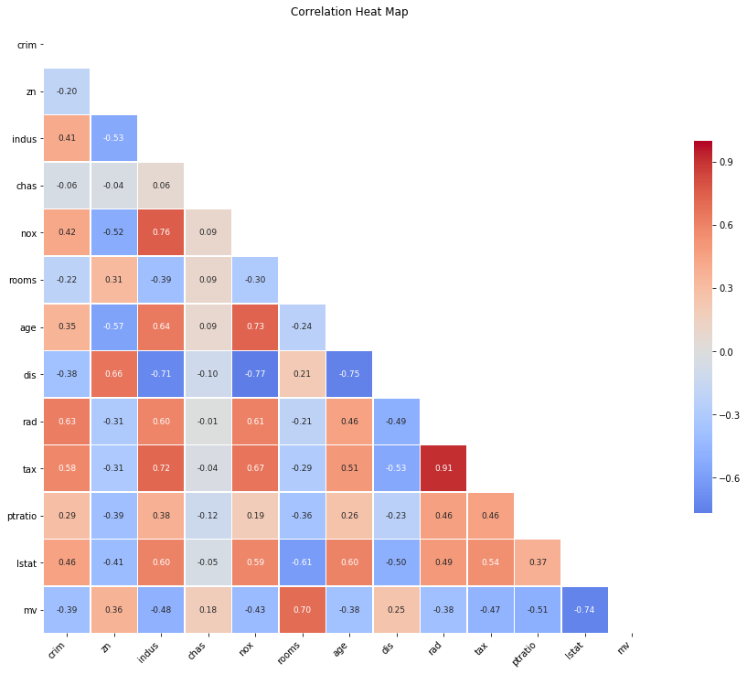

```python
def corr_chart(df_corr):
    corr=df_corr.corr()
    #screen top half to get a triangle
    top = np.zeros_like(corr, dtype=np.bool)
    top[np.triu_indices_from(top)] = True
    fig=plt.figure()
    fig, ax = plt.subplots(figsize=(15,15))
    sns.heatmap(corr, mask=top, cmap='coolwarm',
        center = 0, square=True,
        linewidths=.5, cbar_kws={'shrink':.5},
        annot = True, annot_kws={'size': 9}, fmt = '.2f')
    plt.xticks(rotation=45, ha='right') # rotate variable labels on columns (x axis), add adjustment so text appears right by axis ticks
    plt.yticks(rotation=0) # use horizontal variable labels on rows (y axis)
    plt.title('Correlation Heat Map')

corr_chart(boston_df)
```

From the correlation matrix, there are many relationships that stand out. Here is a highlight:

- rad (radial highways) and tax (tax rate) have a strong positive correlation at .91. Making sure that a model does not suffer from multicollinearity may be key here if both of these variables are included in a model.
- mv (median value) has strong correlations with rooms (positive relationship) and lstat (socioeconomic status - negative relationship). Otherwise, the remaining correlations are weak to moderate. Most relationships are negative.
- dis (employment centers distance) has a strong negative correlation with indus (industrial), nox (air pollution). and age (house age). This result may be due to the fact that the homes from this study are farther out in the suburbs or in areas that are now more built up.

Next, we examine the scatterplot matrix to determine the shape of these relationships. Of note, the Charles River and Radial Highways variables have been omitted from the scatterplot matrix, because they are integer variables.

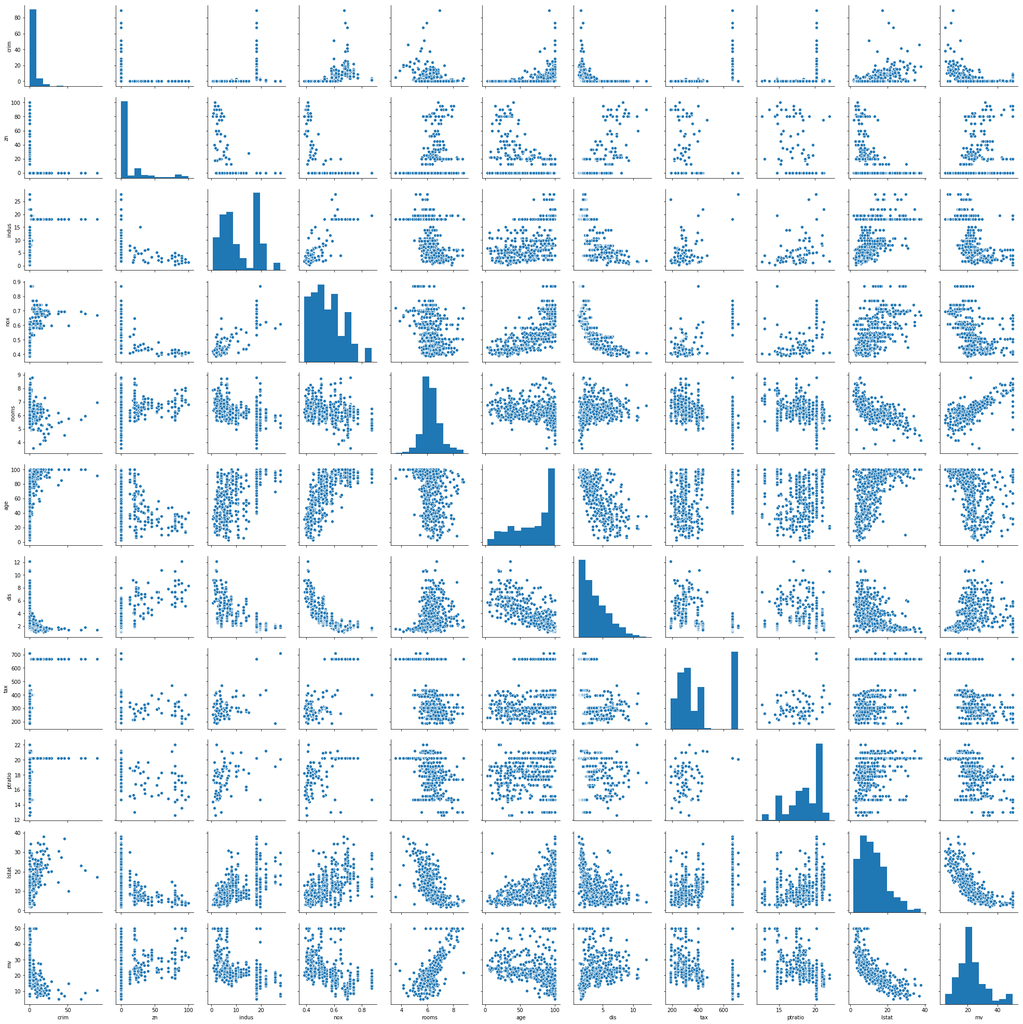

```python
#we select continous vars for scatterplot
#integer and categorical vars have been ommitted
fig.tight_layout()
sns.pairplot(boston_df.loc[:, ~boston_df.columns.isin(['chas', 'rad'])])
plt.show()
```

While the scatterplot matrix is rather large, it is helpful for understanding trends across variables. We can observe the following:

- mv and rooms have a positive linear relationship, but mv and lstat have a curved/nonlinear relationship.
- In general, we can see that there are many other relationships that are curved/nonlinear, such as between dis and nox, dis and rooms, and lstat and rooms.
- There are several cases where the relationships do not appear to be linear and are just a blob of data ponts (i.e, pratio and age).

From all the exploratory data analysis, it is clear that all variables need to be standardized and variable transformations will help in using linear regression methods.

## Data Preparation

In this section, we prepare the data for modeling. As a first step, variables are standardized using the StandardScaler() function to help ensure that the ranges of values are similar for all variables.

```python
boston_modeling_df = boston_df.loc[:, ~boston_df.columns.isin(['neighborhood'])]
cols_ref = boston_modeling_df.columns

from sklearn.exceptions import DataConversionWarning
warnings.filterwarnings(action='ignore', category=DataConversionWarning)

#we standardize the data for modeling
from sklearn.preprocessing import StandardScaler
scaler = StandardScaler()

#we also convert to a data frame
boston_modeling_df = pd.DataFrame(scaler.fit_transform(boston_modeling_df),columns=cols_ref)

#boston_modeling_df.info()
```

To see if variable transformations are also needed, we examine the skewness and kurtosis values for each variable. Skewness is a measure of symmetry, while kurtosis is a measure of the height of the peak of a distribution. We are hoping to see values close to 0 for every variable, as this would indicate that a variable is normally distributed.

```python
from scipy.stats import kurtosis, skew

x = PrettyTable()
x.field_names = ["Variable", "Skewness", "Kurtosis"]
for i in range(len(boston_modeling_df.columns)):
    x.add_row([boston_modeling_df.columns[i], round(skew(boston_modeling_df.loc[i]),2), round(kurtosis(boston_modeling_df.loc[i]),2)])
print(x.get_string(title="Skewness and Kurtosis for Standardized Data"))
```

```
+--------------------------------------------+
| Skewness and Kurtosis for Standardized Data |
+--------------+--------------+--------------+
|   Variable   |   Skewness   |   Kurtosis   |
+--------------+--------------+--------------+
|     crim     |    -0.33     |    -1.22     |
|      zn      |     0.48     |    -0.71     |
|    indus     |     0.98     |    -0.21     |
|     chas     |     0.64     |    -0.95     |
|     nox      |     0.78     |    -0.75     |
|    rooms     |     0.58     |    -0.54     |
|     age      |    -0.26     |     1.66     |
|     dis      |     0.15     |    -0.25     |
|     rad      |     1.13     |     0.69     |
|     tax      |     0.45     |     0.4      |
|   ptratio    |     0.33     |    -0.55     |
|    lstat     |     0.35     |     1.06     |
|      mv      |     0.01     |     0.15     |
+--------------+--------------+--------------+
```

Most variables have small skewness and kurtosis values, although crim, age, rad, lstat all have skewness or kurtosis values greater than one. In general, we are not seeing very large skewness or kurtosis values which is a good sign. For now, we will not transform any variables, but as a next level of iteration, some variables could be transformed.

# Model Building

In this section, three different models will be developed on a training set using an 80/20 split:

- Linear regression
- Ridge regression
- Lasso regression

In addition to traditional goodness of fit statistics, these models will also be evaulated within a cross-validation design using root mean-squared error (RMSE).

```python
X, y = boston_modeling_df.loc[:, ~boston_modeling_df.columns.isin(['mv'])], boston_modeling_df['mv']
X_train, X_test, y_train, y_test = train_test_split(X, y, test_size=0.20, random_state=RANDOM_SEED)

#quick check the size of our new data frames
print(X_train.shape, y_train.shape)
print(X_test.shape, y_test.shape)
```

```
(404, 12) (404,)
(102, 12) (102,)
```

## Baseline Model: Linear Regression

```python
lin_reg = LinearRegression()
lin_reg.fit(X_train, y_train)

#in reading documentation on cross val metrics, only neg_mean_squared_error is one
#therefore, best to create our own metric and call that using cross_val_score
def rmse(y, y_pred):
        return np.sqrt(np.mean((y_pred - y)**2))

rmse_scorer = make_scorer(rmse, greater_is_better=False)

#run the cross validation
score = cross_val_score(lin_reg, X_train, y_train, cv=3, scoring=rmse_scorer)
print("CV RMSE results: ", -1 * score)
print("CV RMSE mean: ", -1 * np.mean(score))
```

```
CV RMSE results:  [0.54952181 0.53615681 0.49893526]
CV RMSE mean:  0.5282046270630971
```

From the cross validation results above, we can see that the mean RMSE across the 3-folds is .528. However, we can see that there is variability in the performance across the folds, as the range is from .499 to .550. These results will become more meaningful as we generate results from other methods. As it stands, we are merely just trying to gauge the performance of this model on data it has not seen before.

Next, we examine traditional goodness of fit statistics to determine the performance of this model.

```python
#calculate GOF metrics as a summary - in future, should make this a function
lin_reg_yhat = lin_reg.predict(X_train)

#r-squared
lin_reg_rsquared = round(r2_score(y_train, lin_reg_yhat),3)

#MSE
lin_reg_mse = mean_squared_error(y_train, lin_reg_yhat)

#RMSE
lin_reg_rmse = round(sqrt(lin_reg_mse),3)

#rounding MSE
lin_reg_mse = round(lin_reg_mse,3)

#MAE
lin_reg_mae = round(mean_absolute_error(y_train, lin_reg_yhat),3)

x = PrettyTable()
x.field_names = ["R-Squared", "MSE", "RMSE", "MAE"]
x.add_row([lin_reg_rsquared, lin_reg_mse, lin_reg_rmse, lin_reg_mae])
print(x.get_string(title="Linear Regression Training Set"))
```

```
+-----------------------------------+
|   Linear Regression Training Set  |
+-----------+-------+-------+-------+
| R-Squared |  MSE  |  RMSE |  MAE  |
+-----------+-------+-------+-------+
|   0.745   | 0.262 | 0.512 | 0.368 |
+-----------+-------+-------+-------+
```

It is worth pointing out that because our variables were centered and scaled, then the resulting goodness of fit statistics are scaled as well and not interpreted in thousands of 1970s dollars.

From the goodness of fit statistics table above, we can see that the R-squared value is fairly high at .745. However, we can see that there are differences in MAE and RMSE. For background, MAE is the average magnitude of errors, while the RMSE takes the square root of the squared difference between the residuals and fitted values. Therefore, RMSE gives more weight to values that are farther away from their actual value. If MAE and RMSE are close together or about equal, then we know that all the errors are of the same magnitude.

In our case, MAE and RMSE are not equal, which tells us that not all errors are of the same magnitude. As a step to improve model fit, residuals could be examined in greater detail to determine if there are influential points that should be removed.

Lastly, we examine residual plots to determine if this model meets the assumptions of linear regression (constant variance, normality).

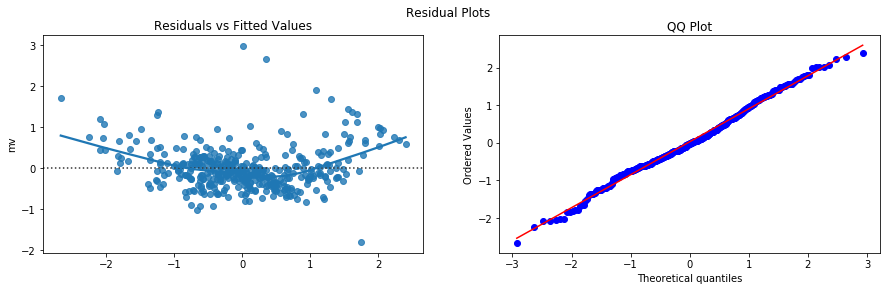

```python
lin_reg_resid = y_train - lin_reg_yhat

fig, axes = plt.subplots(nrows=1, ncols=2, figsize = (15,4))
fig.suptitle('Residual Plots')

ax1 = axes[0]
sns.residplot(lin_reg_yhat, lin_reg_resid, lowess=True, color=current_palette[0], ax=ax1)
ax1.set_title('Residuals vs Fitted Values')

import scipy.stats as stats
import pylab
ax2 = axes[1]
stats.probplot(lin_reg_yhat, dist="norm", plot=pylab)
ax2.set_title('QQ Plot')
pylab.show()
```

From the residual plots, we can see that the normality assumption is met, as the data points fall almost perfectly on the 45-degree line. The assumption of constant variance is not fully met. While the fitted line shows curvature, we can better wee that there are some outlier points that are pulling this line in a nonlinear fashion. Data points near the top and bottom of the Residuals vs Fitted Values should be removed.

## Ridge Regression

Next, we generate a model using ridge regression. Ridge regression utilizes an L2 regularization, which is an additional constraint that helps with overfitting. In this model, the magnitude of the coefficients should be as small as possible.

```python
ridge = Ridge(alpha=1)
ridge.fit(X_train, y_train)

#run the cross validation
score = cross_val_score(ridge, X_train, y_train, cv=3, scoring=rmse_scorer)
print("CV RMSE results: ", -1 * score)
print("CV RMSE mean: ", -1 * np.mean(score))
```

```
CV RMSE results:  [0.55007004 0.53590464 0.49819272]
CV RMSE mean:  0.5280558013738673
```

From the default ridge regression model (alpha = 1), we can see that the CV RMSE results are very similar to the linear regression results.

We examine some additional ridge regression model output by adjusting the alpha parameter. As the alpha parameter increases, coefficients move toward zero. Adjusting this parameter impacts training and test set performance.

```python
#alpha = 10
ridge10 = Ridge(alpha=10)
ridge10.fit(X_train, y_train)
score10 = cross_val_score(ridge10, X_train, y_train, cv=3, scoring=rmse_scorer)
print("Alpha = 10", -1 * score10)
print("Alpha = 10 mean: ", -1 * np.mean(score10))

#alpha = .01
ridge01 = Ridge(alpha=.01)
ridge01.fit(X_train, y_train)
score01 = cross_val_score(ridge01, X_train, y_train, cv=3, scoring=rmse_scorer)
print("Alpha = .01", -1 * score01)
print("Alpha = .01 mean: ", -1 * np.mean(score01))

#see similar performance in cv as linear regression
```

```
Alpha = 10 [0.55510086 0.53586948 0.49502613]
Alpha = 10 mean:  0.5286654932456957
Alpha = .01 [0.54952724 0.53615378 0.49892718]
Alpha = .01 mean:  0.5282027349096657
```

From the CV RMSE results, we can see that the results are very similar to the default ridge regression model and linear regression model results.

A more meaningful analysis can be performed by examining the coefficients from each of the ridge regression models and comparing them to the regression model.

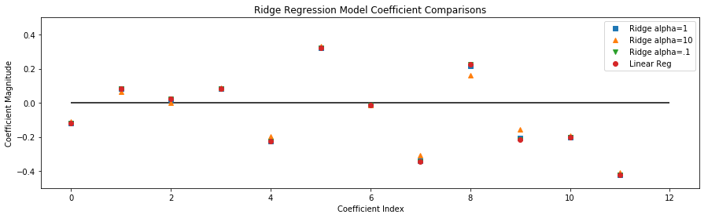

```python
fig, axes = plt.subplots(nrows=1, ncols=1, figsize = (15,4))
plt.plot(ridge.coef_, 's', label = "Ridge alpha=1", color=current_palette[0])
plt.plot(ridge10.coef_, '^', label="Ridge alpha=10", color=current_palette[1])
plt.plot(ridge01.coef_, 'v', label="Ridge alpha=.1", color=current_palette[2])
plt.plot(lin_reg.coef_,'o', label="Linear Reg", color=current_palette[3])
plt.title('Ridge Regression Model Coefficient Comparisons')
plt.xlabel("Coefficient Index")
plt.ylabel("Coefficient Magnitude")
plt.hlines(0,0,len(lin_reg.coef_))
plt.ylim(-.5,.5)
plt.legend(loc="best")
```

From the coefficient plot above, we can see that there are very small differences between each of the models. The alpha = 10 model has coefficients that are slightly closer to zero, while the rest of the models are extremely similar.

To determine which model is best, we need to examine goodness of fit statistics.

```python
#calculate GOF metrics as a summary
ridge_yhat = ridge.predict(X_train)
ridge10_yhat = ridge10.predict(X_train)
ridge01_yhat = ridge01.predict(X_train)

#r-squared
ridge_rsquared = round(r2_score(y_train, ridge_yhat),3)
ridge10_rsquared = round(r2_score(y_train, ridge10_yhat),3)
ridge01_rsquared = round(r2_score(y_train, ridge01_yhat),3)

#MSE
ridge_mse = mean_squared_error(y_train, ridge_yhat)
ridge10_mse = mean_squared_error(y_train, ridge10_yhat)
ridge01_mse = mean_squared_error(y_train, ridge01_yhat)

#RMSE
ridge_rmse = round(sqrt(ridge_mse),3)
ridge10_rmse = round(sqrt(ridge10_mse),3)
ridge01_rmse = round(sqrt(ridge01_mse),3)

#rounding MSE
ridge_mse = round(ridge_mse,3)
ridge10_mse = round(ridge10_mse,3)
ridge01_mse = round(ridge01_mse,3)

#MAE
ridge_mae = round(mean_absolute_error(y_train, ridge_yhat),3)
ridge10_mae = round(mean_absolute_error(y_train, ridge10_yhat),3)
ridge01_mae = round(mean_absolute_error(y_train, ridge01_yhat),3)

x = PrettyTable()
x.field_names = ["Ridge Model", "R-Squared", "MSE", "RMSE", "MAE"]
x.add_row(["Alpha = 1",ridge_rsquared, ridge_mse, ridge_rmse, ridge_mae])
x.add_row(["Alpha = 10",ridge10_rsquared, ridge10_mse, ridge10_rmse, ridge10_mae])
x.add_row(["Alpha = .01",ridge01_rsquared, ridge01_mse, ridge01_rmse, ridge01_mae])
print(x.get_string(title="Ridge Regression Training Set"))
```

```
+-------------------------------------------------+
|          Ridge Regression Training Set          |
+-------------+-----------+-------+-------+-------+
| Ridge Model | R-Squared |  MSE  |  RMSE |  MAE  |
+-------------+-----------+-------+-------+-------+
|  Alpha = 1  |   0.745   | 0.262 | 0.512 | 0.367 |
|  Alpha = 10 |   0.744   | 0.263 | 0.513 | 0.365 |
| Alpha = .01 |   0.745   | 0.262 | 0.512 | 0.368 |
+-------------+-----------+-------+-------+-------+
```

As a final step, we examine residual plots to determine how well this model meets the assumptions of constant variance and normality.

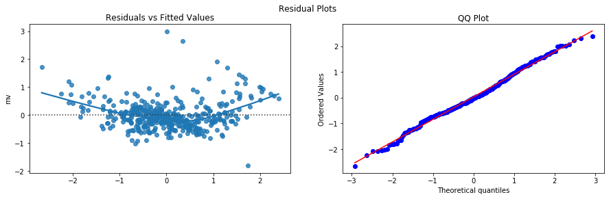

```python
ridge_resid = y_train - ridge_yhat

fig, axes = plt.subplots(nrows=1, ncols=2, figsize = (15,4))
fig.suptitle('Residual Plots')

ax1 = axes[0]
sns.residplot(ridge_yhat, ridge_resid, lowess=True, color=current_palette[0], ax=ax1)
ax1.set_title('Residuals vs Fitted Values')

ax2 = axes[1]
stats.probplot(ridge_yhat, dist="norm", plot=pylab)
ax2.set_title('QQ Plot')
pylab.show()
```

As expected, this model does not have constant variance due to the presence of some large relative residuals.

## Lasso Regression

An alternative model to Ridge regression is Lasso regression. This model uses an L1 regularization, which is more restrictive and creates some coefficients that are exactly zero. This type of model can be beneficial when there are a lot of predictors and only a few are thought to be important.

```python
lasso = Lasso(alpha=1)
lasso.fit(X_train,y_train)

#run the cross validation
score = cross_val_score(lasso, X_train, y_train, cv=3, scoring=rmse_scorer)
print("CV RMSE results: ", -1 * score)
print("CV RMSE mean: ", -1 * np.mean(score))
```

```
CV RMSE results:  [1.04160383 1.0761126  0.91511899]
CV RMSE mean:  1.0109451392743987
```

From the default Lasso model, we can see that the CV RMSE results are way worse than the Ridge and Linear regression models. Therefore, it is likely that a different alpha parameter is needed to experience better training set results.

```python
#alpha = .01
lasso01 = Lasso(alpha=.01)
lasso01.fit(X_train,y_train)
score01 = cross_val_score(lasso01, X_train, y_train, cv=3, scoring=rmse_scorer)
print("Alpha = .01", -1 * score01)
print("Alpha = .01 mean: ", -1 * np.mean(score01))

#alpha = .0001
lasso0001 = Lasso(alpha=.0001)
lasso0001.fit(X_train,y_train)
score0001 = cross_val_score(lasso0001, X_train, y_train, cv=3, scoring=rmse_scorer)
print("Alpha = .0001", -1 * score0001)
print("Alpha = .0001 mean: ", -1 * np.mean(score0001))
```

```
Alpha = .01 [0.55662605 0.53950511 0.49449488]
Alpha = .01 mean:  0.5302086813237248
Alpha = .0001 [0.5495727  0.53612405 0.4988361 ]
Alpha = .0001 mean:  0.5281776192366568
```

From the CV RMSE results above, we can see that the alpha = .0001 results are more comparable to the Ridge and Linear regression models.

Similar to above, we examine the model coefficients to better understand how the alpha parameter is impacting them.

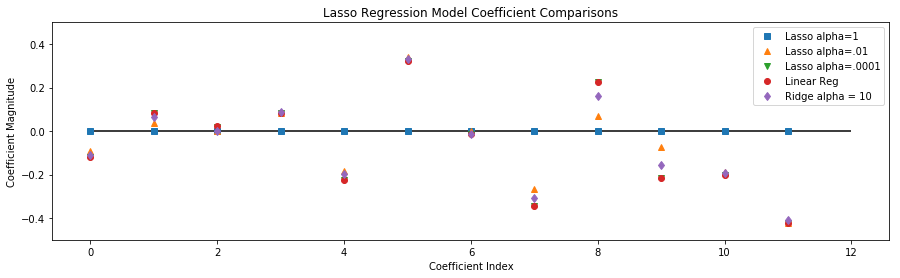

```python
fig, axes = plt.subplots(nrows=1, ncols=1, figsize = (15,4))
plt.plot(lasso.coef_, 's', label = "Lasso alpha=1", color=current_palette[0])
plt.plot(lasso01.coef_, '^', label="Lasso alpha=.01", color=current_palette[1])
plt.plot(lasso0001.coef_, 'v', label="Lasso alpha=.0001", color=current_palette[2])
plt.plot(lin_reg.coef_,'o', label="Linear Reg", color=current_palette[3])
plt.plot(ridge10.coef_,'d', label="Ridge alpha = 10", color=current_palette[4])
plt.title('Lasso Regression Model Coefficient Comparisons')
plt.xlabel("Coefficient Index")
plt.ylabel("Coefficient Magnitude")
plt.hlines(0,0,len(lin_reg.coef_))
plt.ylim(-.5,.5)
plt.legend(loc="best")
```

Right away, we can see that the alpha = 1 model makes all values equal to zero, which is not a helpful model. Therefore, it seems like the alpha = .01 model strikes a better balance as it has a few coefficients that are closer to zero. We can see that the alpha = .0001 model is more similar to Linear regression, which makes sense since a model with alpha = 0 is just linear regression (i.e, no regularization).

We continue exploring the Lasso models by comparing their goodness of fit statistics.

```python
#calculate GOF metrics as a summary
lasso_yhat = lasso.predict(X_train)
lasso01_yhat = lasso01.predict(X_train)
lasso0001_yhat = lasso0001.predict(X_train)

#r-squared
lasso_rsquared = round(r2_score(y_train, lasso_yhat),3)
lasso01_rsquared = round(r2_score(y_train, lasso01_yhat),3)
lasso0001_rsquared = round(r2_score(y_train, lasso0001_yhat),3)

#MSE
lasso_mse = mean_squared_error(y_train, lasso_yhat)
lasso01_mse = mean_squared_error(y_train, lasso01_yhat)
lasso0001_mse = mean_squared_error(y_train, lasso0001_yhat)

#RMSE
lasso_rmse = round(sqrt(lasso_mse),3)
lasso01_rmse = round(sqrt(lasso01_mse),3)
lasso0001_rmse = round(sqrt(lasso0001_mse),3)

#rounding MSE
lasso_mse = round(lasso_mse,3)
lasso01_mse = round(lasso01_mse,3)
lasso0001_mse = round(lasso0001_mse,3)

#MAE
lasso_mae = round(mean_absolute_error(y_train, lasso_yhat),3)
lasso01_mae = round(mean_absolute_error(y_train, lasso01_yhat),3)
lasso0001_mae = round(mean_absolute_error(y_train, lasso0001_yhat),3)

x = PrettyTable()
x.field_names = ["Lasso Model","R-Squared", "MSE", "RMSE", "MAE"]
x.add_row(["Alpha = 1", lasso_rsquared, lasso_mse, lasso_rmse, lasso_mae])
x.add_row(["Alpha = .01", lasso01_rsquared, lasso01_mse, lasso01_rmse, lasso01_mae])
x.add_row(["Alpha = .0001", lasso0001_rsquared, lasso0001_mse, lasso0001_rmse, lasso0001_mae])
print(x.get_string(title="Lasso Regression Training Set"))
```

```
+---------------------------------------------------+
|           Lasso Regression Training Set           |
+---------------+-----------+-------+-------+-------+
|  Lasso Model  | R-Squared |  MSE  |  RMSE |  MAE  |
+---------------+-----------+-------+-------+-------+
|   Alpha = 1   |    0.0    | 1.027 | 1.013 | 0.739 |
|  Alpha = .01  |    0.74   | 0.267 | 0.517 | 0.365 |
| Alpha = .0001 |   0.745   | 0.262 | 0.512 | 0.368 |
+---------------+-----------+-------+-------+-------+
```

We can see that the alpha = 1 is the worst performing model. The alpha = .01 and alpha = .0001 models have very similar performance, but the slight edge goes to the alpha = .0001 model. However, because the performance of these models is so close, both will be considered on the test set. The reason why the alpha = .01 model does slightly worse is because more coefficients are closer to zero. The alpha = .0001 model may fit the training data better, but it also may overfit the training data and thus do worse on the test set. Hence, why both models are being considered.

As a final step, we examine the residuals of only the alpha = .0001 model.

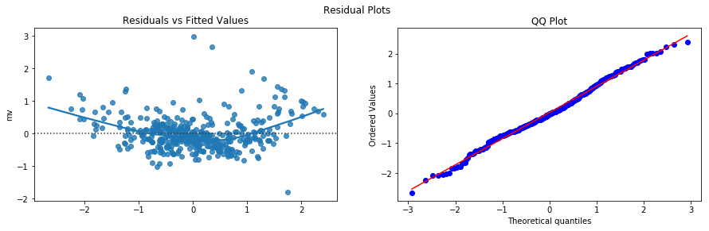

```python
lasso_resid = y_train - lasso0001_yhat

fig, axes = plt.subplots(nrows=1, ncols=2, figsize = (15,4))
fig.suptitle('Residual Plots')

ax1 = axes[0]
sns.residplot(lasso0001_yhat, lasso_resid, lowess=True, color=current_palette[0], ax=ax1)
ax1.set_title('Residuals vs Fitted Values')

ax2 = axes[1]
stats.probplot(lasso0001_yhat, dist="norm", plot=pylab)
ax2.set_title('QQ Plot')
pylab.show()
```

Once again, this model has a shape to its residuals. To help improve the shape so that it is nonconstant, influential points could be examined and/or variable transformations could be performed. There are no concerns on the normality assumption.

# Model Selection

Now that we have explored each of the models on the training set, we need to now examine their performance on the test set to determine the optimal model. Because the Ridge and Lasso regression models each have a regularization parameter to help protect against overfitting, we are hoping to see that these models perform better on the test set.

```python
lin_reg_yhat = lin_reg.predict(X_test)
ridge_yhat = ridge10.predict(X_test)
lasso01_yhat = lasso01.predict(X_test)
lasso0001_yhat = lasso0001.predict(X_test)
```

```python
#calculate GOF metrics as a summary
#r-squared
lin_reg_rsquared = round(r2_score(y_test, lin_reg_yhat),3)
ridge_rsquared = round(r2_score(y_test, ridge_yhat),3)
lasso01_rsquared = round(r2_score(y_test, lasso01_yhat),3)
lasso0001_rsquared = round(r2_score(y_test, lasso0001_yhat),3)

#MSE
lin_reg_mse = mean_squared_error(y_test, lin_reg_yhat)
ridge_mse = mean_squared_error(y_test, ridge_yhat)
lasso01_mse = mean_squared_error(y_test, lasso01_yhat)
lasso0001_mse = mean_squared_error(y_test, lasso0001_yhat)

#RMSE
lin_reg_rmse = round(sqrt(lin_reg_mse),3)
ridge_rmse = round(sqrt(ridge_mse),3)
lasso01_rmse = round(sqrt(lasso01_mse),3)
lasso0001_rmse = round(sqrt(lasso0001_mse),3)

#rounding MSE
lin_reg_mse = round(lin_reg_mse,3)
ridge_mse = round(ridge_mse,3)
lasso01_mse = round(lasso01_mse,3)
lasso0001_mse = round(lasso0001_mse,3)

#MAE
lin_reg_mae = round(mean_absolute_error(y_test, lin_reg_yhat),3)
ridge_mae = round(mean_absolute_error(y_test, ridge_yhat),3)
lasso01_mae = round(mean_absolute_error(y_test, lasso01_yhat),3)
lasso0001_mae = round(mean_absolute_error(y_test, lasso0001_yhat),3)
```

```python
x = PrettyTable()
x.field_names = ["Model Name", "R-Squared", "MSE", "RMSE", "MAE"]
x.add_row(["Linear", lin_reg_rsquared, lin_reg_mse, lin_reg_rmse, lin_reg_mae])
x.add_row(["Ridge", ridge_rsquared, ridge_mse, ridge_rmse, ridge_mae])
x.add_row(["Lasso alpha = .01", lasso01_rsquared, lasso01_mse, lasso01_rmse, lasso01_mae])
x.add_row(["Lasso alpha = .0001", lasso0001_rsquared, lasso0001_mse, lasso0001_rmse, lasso0001_mae])
print(x.get_string(title="Test Set Performance"))
```

```
+---------------------------------------------------------+
|                   Test Set Performance                  |
+---------------------+-----------+-------+-------+-------+
|      Model Name     | R-Squared |  MSE  |  RMSE |  MAE  |
+---------------------+-----------+-------+-------+-------+
|        Linear       |   0.689   | 0.273 | 0.522 | 0.344 |
|        Ridge        |   0.685   | 0.276 | 0.526 | 0.341 |
|  Lasso alpha = .01  |    0.67   | 0.289 | 0.538 | 0.348 |
| Lasso alpha = .0001 |   0.689   | 0.273 | 0.522 | 0.344 |
+---------------------+-----------+-------+-------+-------+
```

From the goodness of fit statistics, we can see that the Lasso alpha = .01 model is the inferior model. The Ridge model does not seem to perform as best as the Linear regression or Lasso alpha = .0001 models.

# Summary and Conclusions

Additionally, while cross validation using RMSE was used to understand how the models performed on new/unseen data, cross validation could be used to tune hyperparameters (i.e., alpha values) and help aid in the decision of which hyperparameters are best. Additional metrics, outside of RMSE, could then be used to evaluate models/hyperparameters and select the best performing model.

Also, while Elastic Net was not considered above, it could be considered in a next iteration, along with Linear, Ridge, and Lasso regression models. By adding more models to the mix, this step will help to ensure that the Lasso model is truly the best model.

Lastly, it would be helpful to have more context on the goals of this model, as this may inform if there are certain types of homes that should be removed altogether. For instance, while the neighborhood variable was removed from this analysis, it could be used as a proxy for data filtering, as median home value varies greatly by neighborhood. This type of extra analysis will help to improve model fit and ensure that the model generalizes well for the business problem.

# Appendix

```python
#calculate VIF - not sure if this is correct
from statsmodels.stats.outliers_influence import variance_inflation_factor

vif = pd.DataFrame()
vif["VIF Factor"] = [variance_inflation_factor(X_train.values, i) for i in range(X_train.shape[1])]
vif["features"] = X_train.columns
vif.round(1)
```

|  | VIF Factor | features |
| --- | --- | --- |
| 0 | 1.7 | crim |
| 1 | 2.5 | zn |
| 2 | 3.9 | indus |
| 3 | 1.1 | chas |
| 4 | 4.4 | nox |
| 5 | 1.9 | rooms |
| 6 | 3.0 | age |
| 7 | 4.2 | dis |
| 8 | 7.6 | rad |
| 9 | 8.9 | tax |
| 10 | 1.9 | ptratio |
| 11 | 2.8 | lstat |